# Model-based clustering using mclust

# Introduction

We use the following packages:

```r
library(mclust)
library(tidyverse)
library(patchwork)
```

In this practical, we will apply model-based clustering on a dataset of bank note measurements. The data is built into the `mclust` package and can be loaded as a `tibble` by running the following code:

```r
df <- as_tibble(banknote)
```

# Data exploration

> Read the help file of the `banknote` dataset to understand what it’s all about.

```r
?banknote
```

> Create a scatter plot of the left (x-axis) and right (y-axis) measurements on the dataset. Map the `Status` column to colour. Jitter the points to avoid overplotting. Are the classes easy to distinguish based on these features?

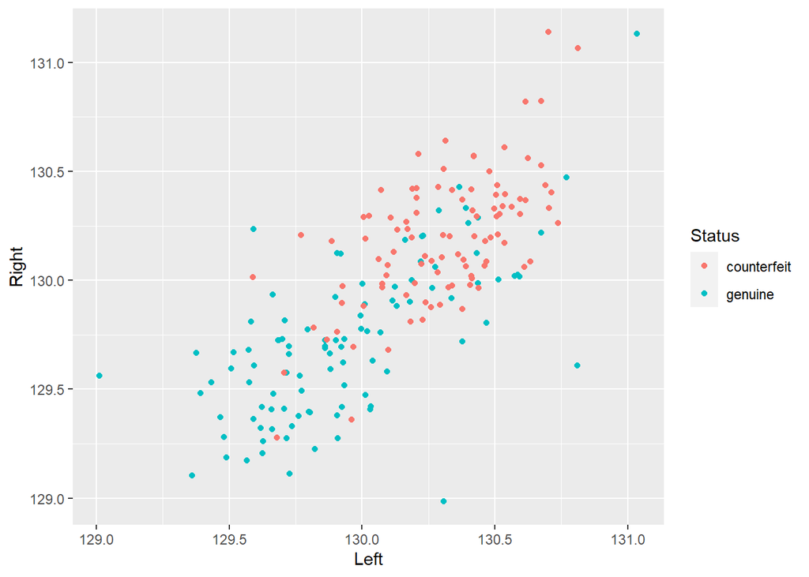

```r
df %>%
  ggplot(aes(x = Left, y = Right, colour = Status)) +
  geom_point(position = position_jitter())
```

```r
# the classes are not easy to distinguish: there is considerable overlap.
```

> From now on, we will assume that we don’t have the labels. Remove the `Status` column from the dataset.

```r
df <- df %>% select(-Status)
```

> Create density plots for all columns in the dataset. Which single feature is likely to be best for clustering?

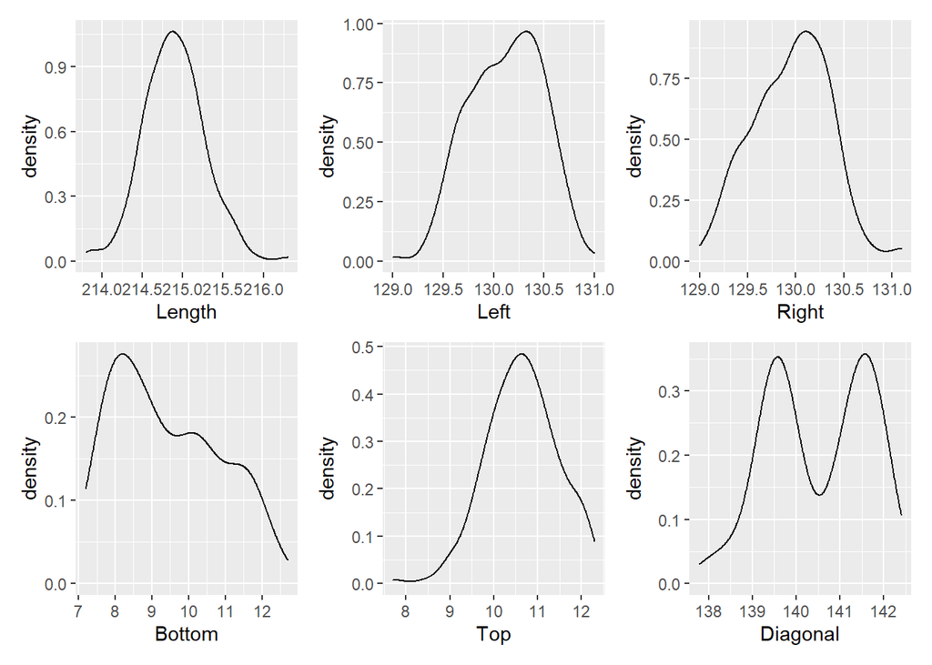

```r
# big patchwork of density plots
df %>% ggplot(aes(x = Length))   + geom_density() +
df %>% ggplot(aes(x = Left))     + geom_density() +
df %>% ggplot(aes(x = Right))    + geom_density() +
df %>% ggplot(aes(x = Bottom))   + geom_density() +
df %>% ggplot(aes(x = Top))      + geom_density() +
df %>% ggplot(aes(x = Diagonal)) + geom_density()
```

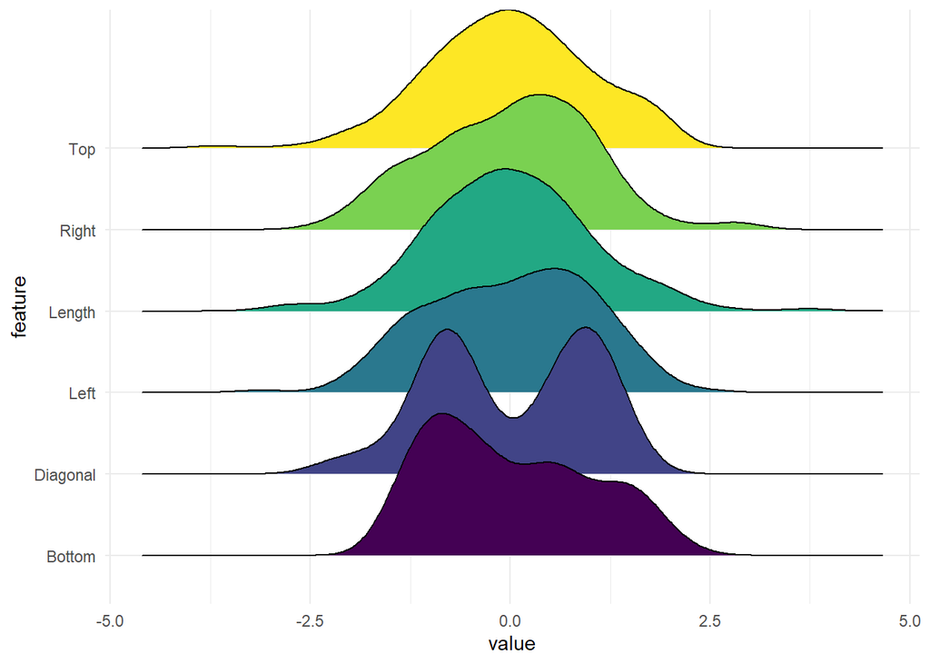

```r
# the Diagonal feature looks good! Look at the two bumps in its density plot.

# alternative:
library(ggridges)
df %>%
  mutate_all(scale) %>%
  pivot_longer(everything(), names_to = "feature", values_to = "value") %>%
  ggplot(aes(x = value, y = feature, fill = feature)) +
  geom_density_ridges() +
  scale_fill_viridis_d(guide = FALSE) +
  theme_minimal()
```

# Univariate model-based clustering

> Use `Mclust` to perform model-based clustering with 2 clusters on the feature you chose. Assume equal variances. Name the model object `fit_E_2`. What are the means and variances of the clusters?

```r
fit_E_2 <- Mclust(df %>% pull(Diagonal), G = 2, modelNames = "E")
# means:
fit_E_2$parameters$mean
```

```
##        1        2
## 139.4464 141.5221
```

```r
# variances:
fit_E_2$parameters$variance$sigmasq
```

```
## [1] 0.244004
```

> Use the formula from the slides and the model’s log-likelihood (`fit_E_2$loglik`) to compute the BIC for this model. Compare it to the BIC stored in the model object (`fit_E_2$bic`). Explain how many parameters (m) you used and which parameters these are.

```r
# This model has 4 parameters: 1 class probability pi, 2 means, and 1 variance
- 2 * fit_E_2$loglik + log(nrow(df)) * 4
```

```
## [1] 569.4667
```

```r
fit_E_2$bic
```

```
## [1] -569.4667
```

```r
# note: the BIC from the Mclust package is negative!
```

> Plot the model-implied density using the `plot()` function. Afterwards, add rug marks of the original data to the plot using the `rug()` function from the base graphics system.

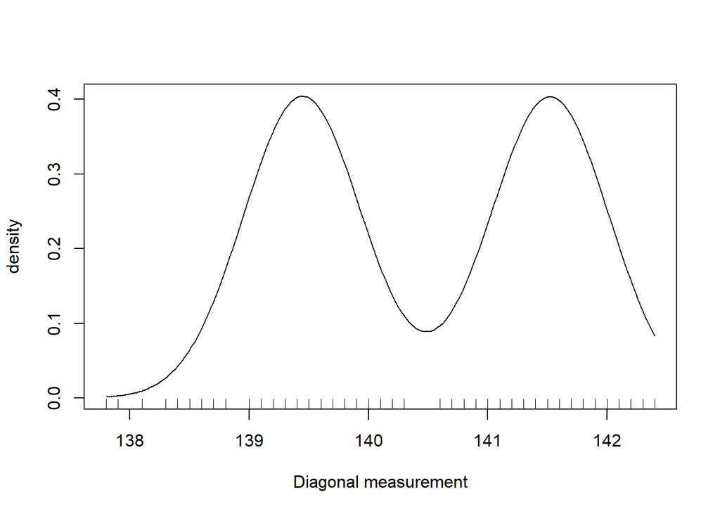

```r
# plot the density using base R plots
plot(fit_E_2, "density", xlab = "Diagonal measurement")
# add the observations using rug marks
rug(df %>% pull(Diagonal))
```

> Use `Mclust` to perform model-based clustering with 2 clusters on this feature again, but now assume *unequal* variances. Name the model object `fit_V_2`. What are the means and variances of the clusters? Plot the density again and note the differences.

```r
fit_V_2 <- Mclust(df %>% pull(Diagonal), G = 2, modelNames = "V")
fit_V_2$parameters$mean
```

```
##        1        2
## 139.4973 141.5604
```

```r
fit_V_2$parameters$variance$sigmasq
```

```
## [1] 0.3589844 0.1500838
```

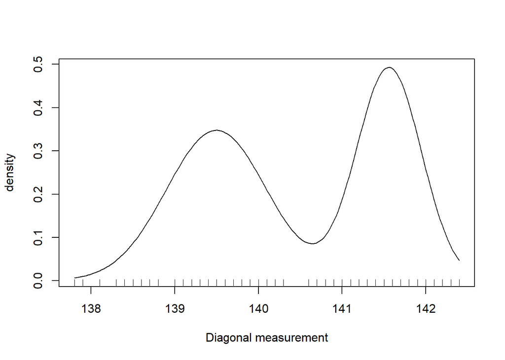

```r
plot(fit_V_2, "density", xlab = "Diagonal measurement")
rug(df %>% pull(Diagonal))
```

```r
# The left cluster has larger variance now, because the data is more spread out
```

> How many parameters does this model have? Name them.

```r
# 5 parameters:
# 1 class probability (pi)
# 2 means
# 2 variances
```

> According to the deviance, which model fits better?

```r
-2*fit_E_2$loglik
```

```
## [1] 548.2735
```

```r
-2*fit_V_2$loglik
```

```
## [1] 537.0199
```

```r
# The V model fits better (lower deviance)
```

> According to the BIC, which model is better?

```r
# remember, the package shows negative BIC
-fit_E_2$bic
```

```
## [1] 569.4667
```

```r
-fit_V_2$bic
```

```
## [1] 563.5115
```

```r
# the V model fits better (lower BIC), but it's closer because of the extra parameter!
```

# Multivariate model-based clustering

We will now use all available information in the dataset to cluster the observations.

> Use Mclust with all 6 features to perform clustering. Allow all model types (shapes), and from 1 to 9 potential clusters. What is the optimal model based on the BIC?

```r
fit <- Mclust(df)
summary(fit)
```

```
## ----------------------------------------------------
## Gaussian finite mixture model fitted by EM algorithm
## ----------------------------------------------------
##
## Mclust VVE (ellipsoidal, equal orientation) model with 3 components:
##
##  log-likelihood   n df       BIC      ICL
##       -663.3814 200 53 -1607.574 -1607.71
##
## Clustering table:
##  1  2  3
## 18 98 84
```

```r
# The optimal model is a VVE model with 3 components
```

> How many mean parameters does this model have?

```r
fit$parameters$mean
```

```
##                [,1]       [,2]      [,3]
## Length   215.023017 214.971360 214.78091
## Left     130.499684 129.929686 130.26435
## Right    130.304813 129.701143 130.17988
## Bottom     8.775842   8.301115  10.85719
## Top       11.173812  10.162379  11.10798
## Diagonal 138.731602 141.541673 139.62387
```

```r
# 3 clusters * 6 variables = 18 mean parameters
```

> Run a 2-component VVV model on this data. Create a matrix of bivariate contour (“density”) plots using the `plot()` function. Which features provide good component separation? Which do not?

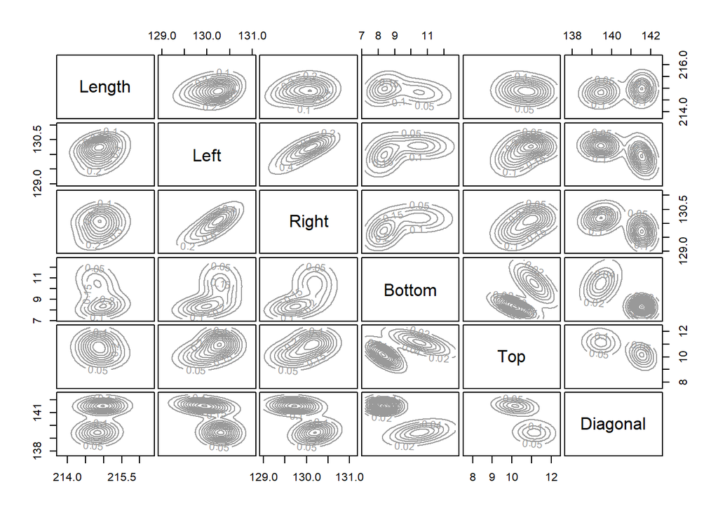

```r
VVV2 <- Mclust(df, 2, "VVV")
plot(VVV2, "density")
```

```r
# Diagonal-top, and diagonal-bottom separate the classes very well!
```

> Create a scatter plot just like the first scatter plot in this tutorial, but map the estimated class assignments to the colour aesthetic. Map the uncertainty (part of the fitted model list) to the size aesthetic, such that larger points indicate more uncertain class assignments. Jitter the points to avoid overplotting. What do you notice about the uncertainty?

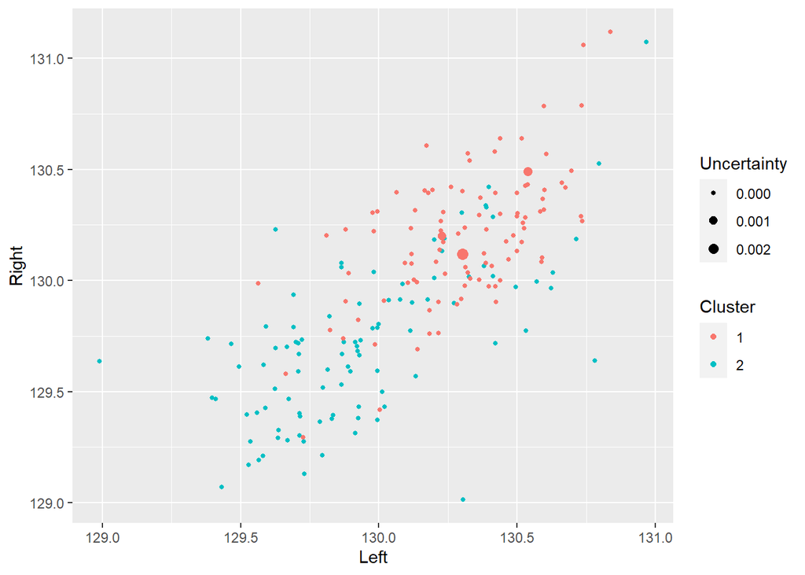

```r
df %>%
  ggplot(aes(
    x      = Left,
    y      = Right,
    colour = as_factor(VVV2$classification),
    size   = VVV2$uncertainty
  )) +
  geom_point(position = position_jitter()) +
  scale_size(range = c(1, 3)) +
  labs(colour = "Cluster", size = "Uncertainty")
```

```r
# only 3 points are slightly uncertain, and they are not around the border of the classes in these two dimensions. The other dimensions give enough information about those points near the border!
```